# extra_week_13_cross_val_score_regression

## CMPINF 2100 Week 13

### Supplemental - Cross-Validation for Regression using `cross_val_score()`

The lecture examples focused on applying cross-validation for Binary Classification problems. Cross-Validation should **not** just be used for Classification! Cross-Validation is an **essential** tool for Classification **and** Regression problems!

The primary purpose of this notebook is to demonstrate the scikit-learn functions needed to apply Cross-Validation using the `cross_val_score()` function for Regression problems. It begins by reviewing how to fit linear models using statsmodels and calculating the important regression performance metrics. The syntax for fitting linear models in scikit-learn are then demonstrated. Please note the scikit-learn implementation shares a lot in common with the syntax for fitting logistic regression models for Binary Classification.

## Import Modules

Begin by importing the "big 4" modules. Other modules and functions will be imported later as needed.

```python
import numpy as np
import pandas as pd
import matplotlib.pyplot as plt

import seaborn as sns
```

## Read data

Let's use the regression example from Week 11. The data were generated as part of the discussion about FEATURES derived from continuous inputs. We generated data with LINEAR ADDITIVE FEATURES.

```python
df11 = pd.read_csv('../week_11/linear_additive_example.csv')
```

The data set includes the REAL ANSWER in the `trend` column. The `y` column is the RANDOMLY generated NOISY output measurements. Thus, the goal is to see how well we can learn the TRUE answer GIVEN the noisy measurements, `y`. There are only 35 rows in this example.

```python
df11.info()
```

```
<class 'pandas.core.frame.DataFrame'>
RangeIndex: 35 entries, 0 to 34
Data columns (total 4 columns):
 #   Column  Non-Null Count  Dtype
---  ------  --------------  -----
 0   x1      35 non-null     float64
 1   x2      35 non-null     float64
 2   trend   35 non-null     float64
 3   y       35 non-null     float64
dtypes: float64(4)
memory usage: 1.2 KB
```

However, create a data set that does **NOT** include the TRUE ANSWER. This way our example is closer to a realistic situation where we collect the measurements of the INPUTS and OUTPUT and we do NOT know the TRUTH!

```python
df = df11.drop(columns={'trend'}).copy()
```

```python
df.info()
```

```
<class 'pandas.core.frame.DataFrame'>
RangeIndex: 35 entries, 0 to 34
Data columns (total 3 columns):
 #   Column  Non-Null Count  Dtype
---  ------  --------------  -----
 0   x1      35 non-null     float64
 1   x2      35 non-null     float64
 2   y       35 non-null     float64
dtypes: float64(3)
memory usage: 968.0 bytes
```

We created the data for this example in Week 11 and so we will not complete a detailed exploration of the data. However, the figure below shows relationships between the OUTPUT and each INPUT via a faceted TREND PLOT. The TREND PLOT reveals a clear linear relationship between `y` and `x1`. The relationship between `y` and `x2` does not appear to be significant.

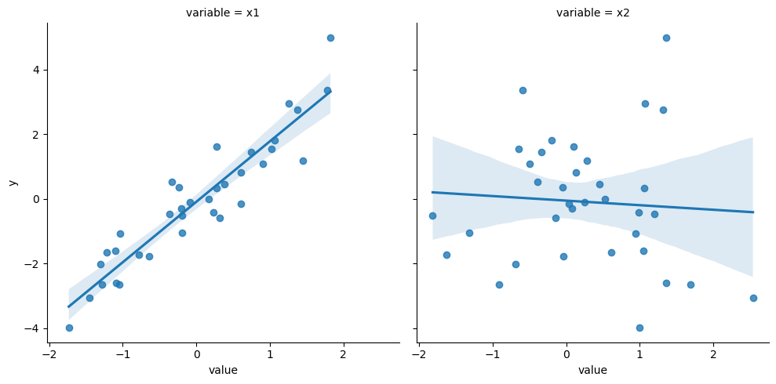

```python
sns.lmplot(data = df.reset_index().rename(columns={'index': 'rowid'}).melt(id_vars=['rowid', 'y']),
           x='value', y='y', col='variable')

plt.show()
```

## Fit linear models

We will define the models using the FORMULA INTERFACE. We fit multiple linear models in Week 11 lecture examples. Let's fit those models, as well as some additional ones in this notebook. The formulas for all models are defined within the list below. The zeroth formula is the INTERCEPT-ONLY or CONSTANT AVERAGE model. The one formula is the model with LINEAR ADDITIVE FEATURES. We know this is the correct answer! The second model includes the main effect linear features and the interaction (product) between the two inputs. The third model is additive between the inputs but includes the quadratic features derived from the two inputs. The fourth model includes the main effect linear features, the interaction between the two inputs, and the quadratic features. The fifth model is additive between the two inputs, but derives quadratic and cubic features from each input. The last model interacts all features derived from `x1` with all features derived from `x2`. Only linear and quadratic features are included in the last model, but this model includes interactions which the previous model does not.

```python
formula_list = ['y ~ 1',
                'y ~ x1 + x2',
                'y ~ x1 * x2',
                'y ~ x1 + x2 + np.power(x1, 2) + np.power(x2, 2)',
                'y ~ x1 * x2 + np.power(x1, 2) + np.power(x2, 2)',
                'y ~ x1 + x2 + np.power(x1, 3) + np.power(x2, 2) + np.power(x1, 3) + np.power(x2, 3)',
                'y ~ ( x1 + np.power(x1, 2) ) * ( x2 + np.power(x2, 2) )']
```

### statsmodels

Let's begin by fitting the models with the statsmodels formula interface.

```python
import statsmodels.formula.api as smf
```

We will not manaully fit each model in this notebook. Instead, we will define a function which fits and assess the linear model on the TRAINING SET only. This function is analogous to teh `fit_and_assess_logistic()` function from the Week 12 multiple models example. The difference of course is that this we are fitting LINEAR MODELS and thus use the `smf.ols()` function instead of `smf.logit()`. The function is named `fit_and_assess_ols()` to reflect that we are fitting linear models for regression.

The Regression performance metrics R-squared and RMSE are returned. The R-squared is extracted using the `.rsquared` attribute while the RMSE is calculated based on the `.resid` attribute. Therefore, the training set does NOT need predicted as in the Classification case to calculate the training set performance!

```python
def fit_and_assess_ols(mod_name, a_formula, the_data):
    a_mod = smf.ols(formula=a_formula, data=the_data).fit()

    res_dict = {'model_name': mod_name,
                'model_formula': a_formula,
                'num_coefs': len( a_mod.params ),
                'R-squared': a_mod.rsquared,
                'RMSE': np.sqrt( (a_mod.resid **2 ).mean() )}

    return pd.DataFrame( res_dict, index=[0] )
```

Let's test the function on the INTERCEPT-ONLY model.

```python
fit_and_assess_ols( 0, formula_list[0], df )
```

|  | model_name | model_formula | num_coefs | R-squared | RMSE |
| --- | --- | --- | --- | --- | --- |
| 0 | 0 | y ~ 1 | 1 | 0.0 | 1.939479 |

Let's apply the `fit_and_asses_ols()` function to all formulas.

```python
ols_results_list = []

for m in range( len(formula_list) ):
    ols_results_list.append( fit_and_assess_ols( m, formula_list[m], df ) )
```

Nothing is printed to the screen because fitting regression models with OLS does NOT require any optimization algorithm to be executed! Known formulas are used to fit the model!

Combine all model results together into a single DataFrame.

```python
ols_results_df = pd.concat( ols_results_list, ignore_index=True )
```

```python
ols_results_df
```

|  | model_name | model_formula | num_coefs | R-squared | RMSE |
| --- | --- | --- | --- | --- | --- |
| 0 | 0 | y ~ 1 | 1 | 0.000000 | 1.939479 |
| 1 | 1 | y ~ x1 + x2 | 3 | 0.874142 | 0.688058 |
| 2 | 2 | y ~ x1 * x2 | 4 | 0.889187 | 0.645625 |
| 3 | 3 | y ~ x1 + x2 + np.power(x1, 2) + np.power(x2, 2) | 5 | 0.876315 | 0.682094 |
| 4 | 4 | y ~ x1 * x2 + np.power(x1, 2) + np.power(x2, 2) | 6 | 0.890730 | 0.641115 |
| 5 | 5 | y ~ x1 + x2 + np.power(x1, 3) + np.power(x2, 2... | 6 | 0.899866 | 0.613726 |
| 6 | 6 | y ~ ( x1 + np.power(x1, 2) ) * ( x2 + np.power... | 9 | 0.920803 | 0.545806 |

**Why does this matter?**

We know the right answer for this example! We know the model with formula `y ~ x1 + x2` is the correct answer! That model GENERATED the data! However, the TRAINING set performance metrics do NOT select that model as the best!

Let's fit the statsmodles object directly for the correct model and for the identified BEST model.

```python
fit_01 = smf.ols(formula=formula_list[1], data=df).fit()
```

```python
fit_06 = smf.ols(formula=formula_list[6], data=df).fit()
```

The `my_coefplot()` function is defined below.

```python
def my_coefplot(mod, figsize_use=(10, 4)):
    fig, ax = plt.subplots(figsize=figsize_use)

    ax.errorbar( y=mod.params.index,
                 x=mod.params,
                 xerr = 2 * mod.bse,
                 fmt='o', color='k', ecolor='k', elinewidth=2, ms=10)

    ax.axvline(x=0, linestyle='--', linewidth=3.5, color='grey')

    ax.set_xlabel('coefficient value')

    plt.show()
```

The `fit_01` model which used the LINEAR ADDITIVE FEATURES shows that only `x1` is statistically significant!

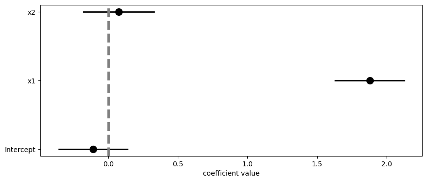

```python
my_coefplot(fit_01)
```

The `fit_06` model which includes the interactions and non-linear relationships also has statistically sigificant features! However, we know that this model is wrong! Thus, statistically significant features **do not** mean a model is CORRECT!

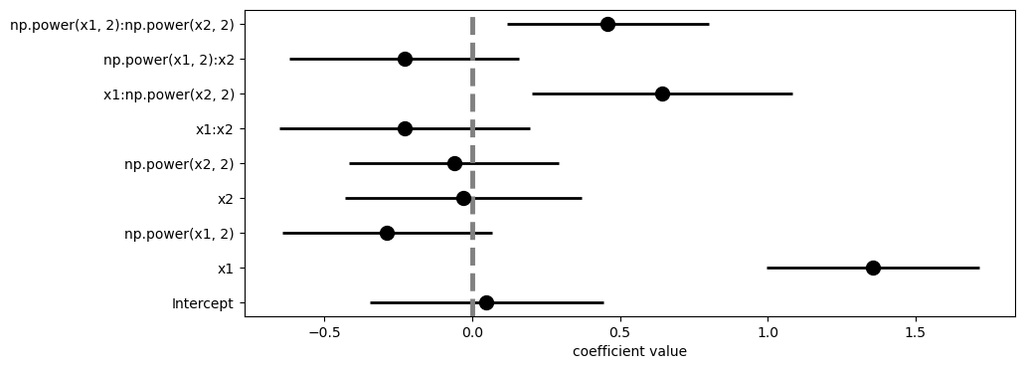

```python
my_coefplot(fit_06)
```

Let's define a visualization grid to study the predictive TREND and the UNCERTAINTY INTERVALS for the two models. We will focus on `x1` as the primary because it's main effect has the largest MAGNITUDE coefficient in the BEST model (we also know that is the input with the higher effect for this application). Let's FIX `x2` at a constant value for now so that we can visualize the UNCERTAINTY intervals as ribbon plots. However, we will use 2 grids. One will use a lower value of `x2` and the second will use a larger value of `x2`. This allows us to visually study the impact of `x2` on the predictions with respect to `x1`.

Begin with the `x1` variable is defined as 151 uniformly spaced points between the training set minimum and maximum. The `x2` variable is fixed at the midpoint between its minimum and average values. This way we are locating `x2` in its LOWER half.

```python
dfviz_1a = pd.DataFrame({'x1': np.linspace(df.x1.min()-0.02, df.x1.max()+0.02, num=151)})
dfviz_1a['x2'] = 0.5 * (df.x1.min() + df.x1.mean())
```

The `.nunique()` method confirms the number of unique values per variable.

```python
dfviz_1a.nunique()
```

```
x1    151
x2      1
dtype: int64
```

The single `x2` value is shown below.

```python
dfviz_1a.x2.value_counts()
```

```
-0.866828    151
Name: x2, dtype: int64
```

The predictions are made and summarized in a single line of code below for each model.

```python
pred_summary_01_1a = fit_01.get_prediction( dfviz_1a ).summary_frame()
```

```python
pred_summary_06_1a = fit_06.get_prediction( dfviz_1a ).summary_frame()
```

The `.head()` is displayed below to show the result has the same structure as the lecture examples.

```python
pred_summary_01_1a.head()
```

|  | mean | mean_se | mean_ci_lower | mean_ci_upper | obs_ci_lower | obs_ci_upper |
| --- | --- | --- | --- | --- | --- | --- |
| 0 | -3.471432 | 0.303200 | -4.089030 | -2.853835 | -5.061986 | -1.880879 |
| 1 | -3.426374 | 0.300827 | -4.039138 | -2.813611 | -5.015058 | -1.837691 |
| 2 | -3.381316 | 0.298465 | -3.989270 | -2.773362 | -4.968151 | -1.794482 |
| 3 | -3.336258 | 0.296116 | -3.939427 | -2.733089 | -4.921265 | -1.751250 |
| 4 | -3.291200 | 0.293780 | -3.889610 | -2.692790 | -4.874402 | -1.707997 |

```python
pred_summary_06_1a
```

|  | mean | mean_se | mean_ci_lower | mean_ci_upper | obs_ci_lower | obs_ci_upper |
| --- | --- | --- | --- | --- | --- | --- |
| 0 | -2.758328 | 0.720912 | -4.240183 | -1.276473 | -4.730714 | -0.785942 |
| 1 | -2.730827 | 0.701695 | -4.173182 | -1.288472 | -4.673712 | -0.787943 |
| 2 | -2.703033 | 0.682787 | -4.106522 | -1.299544 | -4.617241 | -0.788825 |
| 3 | -2.674945 | 0.664189 | -4.040205 | -1.309685 | -4.561303 | -0.788587 |
| 4 | -2.646563 | 0.645903 | -3.974236 | -1.318891 | -4.505898 | -0.787228 |
| ... | ... | ... | ... | ... | ... | ... |
| 146 | 4.366248 | 0.911123 | 2.493407 | 6.239089 | 2.085471 | 6.647025 |
| 147 | 4.436638 | 0.931030 | 2.522880 | 6.350397 | 2.122144 | 6.751133 |
| 148 | 4.507322 | 0.951247 | 2.552007 | 6.462638 | 2.158350 | 6.856295 |
| 149 | 4.578300 | 0.971774 | 2.580789 | 6.575811 | 2.194089 | 6.962511 |
| 150 | 4.649572 | 0.992611 | 2.609230 | 6.689913 | 2.229364 | 7.069779 |

151 rows × 6 columns

The predictions associated with `fit_01`, the model with LINEAR ADDITIVE FEATURES, is shown below. It shows a diagonal line from the lower left to the upper right. This model captures linear relationships and so the predictions are of linear relatinships!

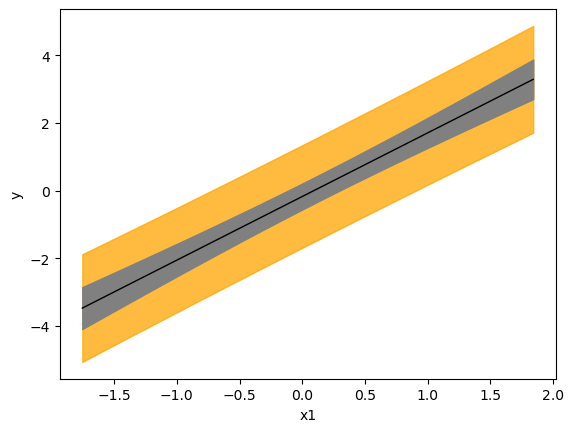

```python
fig, ax = plt.subplots()

# prediction interval
ax.fill_between( dfviz_1a.x1,
                 pred_summary_01_1a.obs_ci_lower, pred_summary_01_1a.obs_ci_upper,
                 facecolor='orange', alpha=0.75, edgecolor='orange')

# confidence interval
ax.fill_between( dfviz_1a.x1,
                 pred_summary_01_1a.mean_ci_lower, pred_summary_01_1a.mean_ci_upper,
                 facecolor='grey', edgecolor='grey')

# trend
ax.plot( dfviz_1a.x1, pred_summary_01_1a['mean'], color='k', linewidth=1)

# set the labels
ax.set_xlabel('x1')
ax.set_ylabel('y')

# show the plot
plt.show()
```

The predictions associated with `fit_06`, the one with the non-linearities and interactions, are shown below. The CONFIDENCE INTERVALS are wider than those associated with `fit_01` and the output to input relationship includes a slight parabolic trend. The "bowl" is roughly shaped upward.

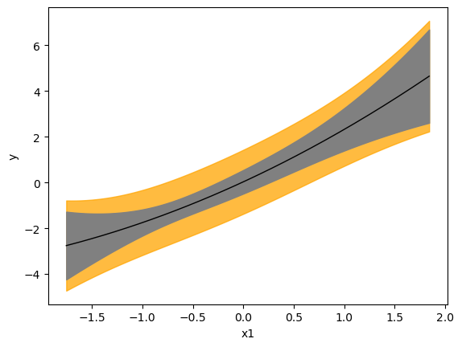

```python
fig, ax = plt.subplots()

# prediction interval
ax.fill_between( dfviz_1a.x1,
                 pred_summary_06_1a.obs_ci_lower, pred_summary_06_1a.obs_ci_upper,
                 facecolor='orange', alpha=0.75, edgecolor='orange')

# confidence interval
ax.fill_between( dfviz_1a.x1,
                 pred_summary_06_1a.mean_ci_lower, pred_summary_06_1a.mean_ci_upper,
                 facecolor='grey', edgecolor='grey')

# trend
ax.plot( dfviz_1a.x1, pred_summary_06_1a['mean'], color='k', linewidth=1)

# set the labels
ax.set_xlabel('x1')
ax.set_ylabel('y')

# show the plot
plt.show()
```

Typically it is best practice to set costant values for prediction at values near the center point. The `x2` value was NOT set to its average or median so that we can directly constrast with a value in the upper half of `x2`. The cell below defines a second visualization grid. But this time, `x2` is set to a value above its average.

```python
dfviz_1b = pd.DataFrame({'x1': np.linspace(df.x1.min()-0.02, df.x1.max()+0.02, num=151)})
dfviz_1b['x2'] = 0.5 * (df.x1.mean() + df.x1.max())
```

```python
dfviz_1b.nunique()
```

```
x1    151
x2      1
dtype: int64
```

The single `x2` value is shown below.

```python
dfviz_1b.x2.value_counts()
```

```
0.911184    151
Name: x2, dtype: int64
```

Predictions on the new visualization are made and summarized.

```python
pred_summary_01_1b = fit_01.get_prediction( dfviz_1b ).summary_frame()
```

```python
pred_summary_06_1b = fit_06.get_prediction( dfviz_1b ).summary_frame()
```

The predictive TREND and UNCERTAINTY INTERVALS are visualized for `fit_01`. It looks very similar to the previous predictions with respect to `x1` for `fit_01`. **Do you know why CHANGING the value of `x2` does NOT produce a subtantial change in the average output?**

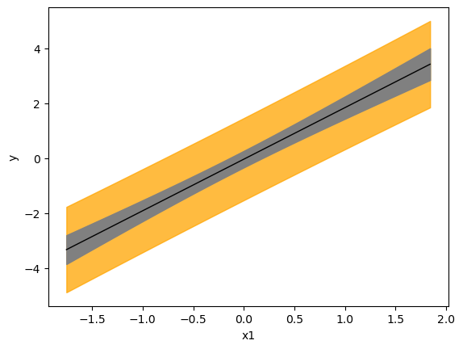

```python
fig, ax = plt.subplots()

# prediction interval
ax.fill_between( dfviz_1b.x1,
                 pred_summary_01_1b.obs_ci_lower, pred_summary_01_1b.obs_ci_upper,
                 facecolor='orange', alpha=0.75, edgecolor='orange')

# confidence interval
ax.fill_between( dfviz_1b.x1,
                 pred_summary_01_1b.mean_ci_lower, pred_summary_01_1b.mean_ci_upper,
                 facecolor='grey', edgecolor='grey')

# trend
ax.plot( dfviz_1b.x1, pred_summary_01_1b['mean'], color='k', linewidth=1)

# set the labels
ax.set_xlabel('x1')
ax.set_ylabel('y')

# show the plot
plt.show()
```

Can you see the difference in the predictions for the higher value of `x2` compared to the previous lower value of `x2`? The inflection of the curve is different from the curve predicted at the lower value of `x2`. The "bowl" is open slightly downward due to the change in the value of `x2`.

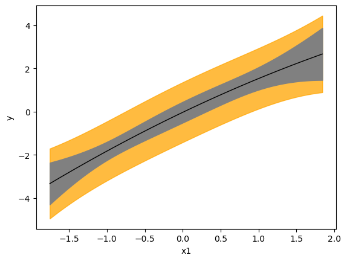

```python
fig, ax = plt.subplots()

# prediction interval
ax.fill_between( dfviz_1b.x1,
                 pred_summary_06_1b.obs_ci_lower, pred_summary_06_1b.obs_ci_upper,
                 facecolor='orange', alpha=0.75, edgecolor='orange')

# confidence interval
ax.fill_between( dfviz_1b.x1,
                 pred_summary_06_1b.mean_ci_lower, pred_summary_06_1b.mean_ci_upper,
                 facecolor='grey', edgecolor='grey')

# trend
ax.plot( dfviz_1b.x1, pred_summary_06_1b['mean'], color='k', linewidth=1)

# set the labels
ax.set_xlabel('x1')
ax.set_ylabel('y')

# show the plot
plt.show()
```

The previous predictions focused on the relationship with respect to `x1`. We saw the impact of `x2` by making two separate sets of predictions. We made two sets because we included BOTH types of uncertainty intervals. However, if we want to include the effect of BOTH inputs at the same time the figure will be very busy. Therefore, we will focus on the predictive TRENDS alone rather than including the UNCERTAINTY. This means we can create a visualization grid that has BOTH inputs changing at the same time. This visualization grid is created below using a nested LIST COMPREHENSION. The grid below treats `x1` as the primary input with 101 unique values while `x2` is treated as the secondary input with 9 unique values. The `.nunique()` method is used to confirm the number of unique values for each input.

```python
input_grid_1 = pd.DataFrame([ (x1, x2) for x1 in np.linspace(df.x1.min(), df.x1.max(), num=101)
                                       for x2 in np.linspace(df.x2.min(), df.x2.max(), num=9)],
                             columns=['x1', 'x2'])
```

```python
input_grid_1.nunique()
```

```
x1    101
x2      9
dtype: int64
```

We can use the `.predict()` method instead of `.get_prediction()` since we are only focused on the TREND (AVERAGE OUTPUT). The `input_grid_1` is copied and then the predictions are included as new COLUMNS. The predicted TREND for `fit_01` is named `pred_01` and the predicted TREND for `fit_06` is named `pred_06`.

```python
dfviz_1 = input_grid_1.copy()
```

```python
dfviz_1['pred_01'] = fit_01.predict( input_grid_1 )
```

```python
dfviz_1['pred_06'] = fit_06.predict( input_grid_1 )
```

The `dfviz_1` head is displayed below to confirm the columns were added correctly.

```python
dfviz_1.head()
```

|  | x1 | x2 | pred_01 | pred_06 |
| --- | --- | --- | --- | --- |
| 0 | -1.733671 | -1.813330 | -3.505384 | -1.911260 |
| 1 | -1.733671 | -1.269344 | -3.464267 | -2.429809 |
| 2 | -1.733671 | -0.725357 | -3.423149 | -2.827037 |
| 3 | -1.733671 | -0.181371 | -3.382032 | -3.102943 |
| 4 | -1.733671 | 0.362615 | -3.340914 | -3.257528 |

Let's now visualize the TREND (AVERAGE OUTPUT) with respect to `x1` for each unique value of `x2`. The figure below shows the predictions for `fit_01`, the model with LINEAR ADDITIVE FEATURES. The lines are colored by `x2` with a diverging color palette to make it easier to see predictions associated with lower values of `x2` compared to predictions associated with higher values of `x2`. The TREND increases as `x1` increaeses. The effect of `x2` is to SHIFT the line upward as `x2` increases. However, the lines are close together reflecting the fact that `x2` does not contribute much to the model behavior.

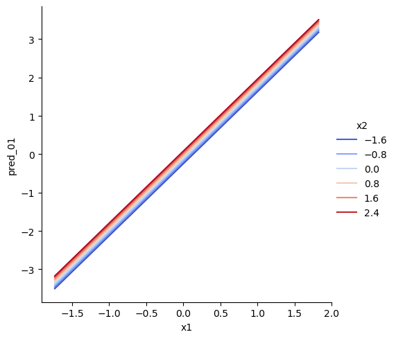

```python
sns.relplot(data = dfviz_1, x='x1', y='pred_01', kind='line',
            hue='x2', estimator=None, units='x2',
            palette='coolwarm')

plt.show()
```

In contrast, the more complex `fit_06` model predicts different behavior with respect to `x1` for each unique value of `x2`. We can clearly see the separate lines in the figure below. We also see that some of the lines are parabolic in shape while others are more linear in shape. The `fit_06` model fully interacted the `x1` FEATURES with the `x2` FEATURES. This means the relationship of the TREND with respect to `x1` is allowed to DEPEND on `x2`. That is exactly what the predictions reveal!

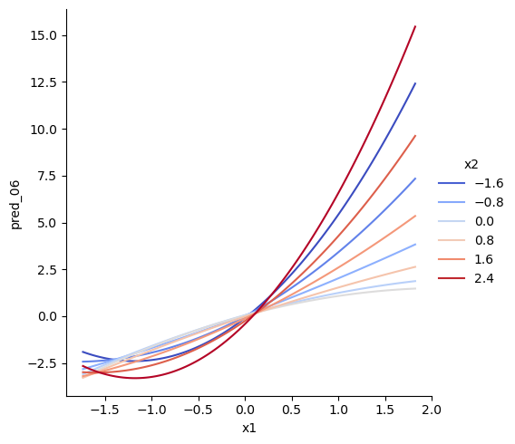

```python
sns.relplot(data = dfviz_1, x='x1', y='pred_06', kind='line',
            hue='x2', estimator=None, units='x2',
            palette='coolwarm')

plt.show()
```

Let's perform one last set of predictions. This last set will treat `x2` as the primary input with 101 unique values while `x1` is the secondary input with 9 unique values. This grid therefore lets us focus on the relationship with respect to `x2`. The `fit_01` model's coefficients revealed `x2` is NOT statistically significant so the predictions will confirm that is the case. The `.nunique()` method is applied to `input_grid_2` below to confirm that `x2` has more unique values than `x1` in this data set.

```python
input_grid_2 = pd.DataFrame([ (x1, x2) for x1 in np.linspace(df.x1.min(), df.x1.max(), num=9)
                                       for x2 in np.linspace(df.x2.min(), df.x2.max(), num=101)],
                             columns=['x1', 'x2'])
```

```python
input_grid_2.nunique()
```

```
x1      9
x2    101
dtype: int64
```

The predictions for `fit_01` and `fit_06` are made on `input_grid_2` following the same steps used previously.

```python
dfviz_2 = input_grid_2.copy()
```

```python
dfviz_2['pred_01'] = fit_01.predict( input_grid_2 )
```

```python
dfviz_2['pred_06'] = fit_06.predict( input_grid_2 )
```

```python
dfviz_2.head()
```

|  | x1 | x2 | pred_01 | pred_06 |
| --- | --- | --- | --- | --- |
| 0 | -1.733671 | -1.813330 | -3.505384 | -1.911260 |
| 1 | -1.733671 | -1.769811 | -3.502095 | -1.957208 |
| 2 | -1.733671 | -1.726292 | -3.498806 | -2.002381 |
| 3 | -1.733671 | -1.682773 | -3.495516 | -2.046776 |
| 4 | -1.733671 | -1.639254 | -3.492227 | -2.090395 |

The predicted TREND (AVERAGE OUTPUT) for `fit_01` on `input_grid_2` is visuailized below. The `x` argument is set to `x2` and the `hue` argument is set to `x1`. The arguments are therefore FLIPPED compared to the previous set of figures. A diverging color palette is still used in order to easily compare lower values of `x1` with higher valuse of `x1`. Each line has a shallow positive slope representing the AVERAGE OUTPUT does NOT increase that much as `x2` increases. This is exactly what we saw previously with the coefficient estimate for `x2`. The estimate was positive and close to zero AND the coefficient was NOT statistically significant. The separate colored lines are "far" apart because each line is a distinct value of `x1`. The AVERAGE OUTPUT increases more substantially for changes in `x1`, as shown by the coefficient estimate and by the previous figure. Please note we examined plots very similar to these back in Week 11. Those plots were created as part of introducing ADDITIVE features. The difference with these figures and those from Week 11 is that these figures are produced from models FIT to the random data.

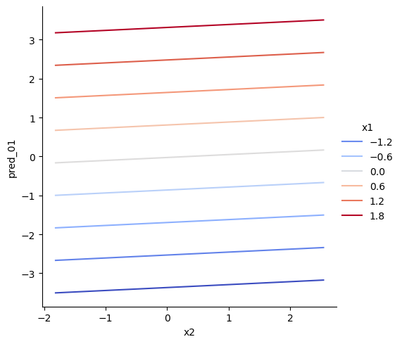

```python
sns.relplot(data = dfviz_2, x='x2', y='pred_01', kind='line',
            hue='x1', estimator=None, units='x1',
            palette='coolwarm')

plt.show()
```

The predictions on `input_grid_2` for the `fit_06` model are visualized below. As with the previous figure, the `x` argument is set to `x2` and the `hue` argument is set to `x1`. The AVERAGE OUTPUT looks like a PARABOLA with respect to `x2` but the shape of the parabola DEPENDS on `x1`. Again this is because `fit_06` INTERACTS all FEATURES from `x1` with all FEATURES from `x2`!

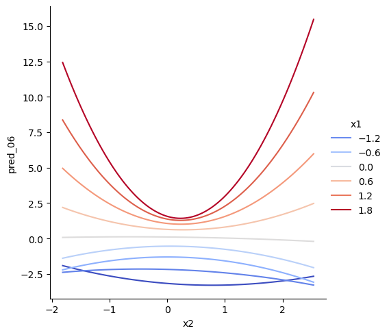

```python
sns.relplot(data = dfviz_2, x='x2', y='pred_06', kind='line',
            hue='x1', estimator=None, units='x1',
            palette='coolwarm')

plt.show()
```

**Why does this matter?**

The TRAINING set performance metrics identified `fit_06` as the BEST model! The `ols_results_df` is SORTED below based on the `RMSE` column to confirm this. The model with the MOST coefficients **APPEARS** to be the BEST! But, we created the data for this problem. We know the correct answer! We know that `fit_01` **IS** the correct model! Why did the performance metrics **NOT** identify `fit_01` as the best? Because, TRAINING set performance IMPROVES as more FEATURES are included! More features means more COEFFICIENTS must be estimated. Therefore, the more coefficients estimated in a model the better the TRAINING set performance becomes!

```python
ols_results_df.sort_values('RMSE')
```

|  | model_name | model_formula | num_coefs | R-squared | RMSE |
| --- | --- | --- | --- | --- | --- |
| 6 | 6 | y ~ ( x1 + np.power(x1, 2) ) * ( x2 + np.power... | 9 | 0.920803 | 0.545806 |
| 5 | 5 | y ~ x1 + x2 + np.power(x1, 3) + np.power(x2, 2... | 6 | 0.899866 | 0.613726 |
| 4 | 4 | y ~ x1 * x2 + np.power(x1, 2) + np.power(x2, 2) | 6 | 0.890730 | 0.641115 |
| 2 | 2 | y ~ x1 * x2 | 4 | 0.889187 | 0.645625 |
| 3 | 3 | y ~ x1 + x2 + np.power(x1, 2) + np.power(x2, 2) | 5 | 0.876315 | 0.682094 |
| 1 | 1 | y ~ x1 + x2 | 3 | 0.874142 | 0.688058 |
| 0 | 0 | y ~ 1 | 1 | 0.000000 | 1.939479 |

The TRAINING set does **NOT** know the GENERAL relationships between the OUTPUT and INPUTS. Models with many FEATURES can **OVERFIT** the TRAINING because they are able to MEMORIZE the behavior contained in the TRAINING set. Visualizing predictive TRENDS on NEW data give us greater insight into the model behavior. For example, we can easily see that `fit_06` is associated with parabolas with respect to `x2` that depend on `x1`! The APPARENT best model consists of those patterns!

### scikit-learn

We learned how to fit LOGISTIC REGRESSION models using the scikit-learn module in lecture. The syntax for fitting LINEAR MODELS for regression problems is similar and follows a similar format. However, the functions are different because regression tasks are different from classification tasks. Therefore you **cannot** use the `LogisticRegression()` function for REGRESSION!

Linear models for REGERSSION are fit via the `LinearRegression()` function. This function is imported from the `sklearn.linear_model` module below. This is the SAME module that we imported `LogisticRegression()` from for binary classification.

```python
from sklearn.linear_model import LinearRegression
```

The `LinearRegression()` function also works with the ARRAY INTERFACE like `LogisticRegressio()`. We therefore need to import the `dmatrices()` function from the `patsy` module just like we did in the lecture example.

```python
from patsy import dmatrices
```

Let's first demonstrate fitting the linear model with scikit-learn for the model with LINEAR ADDITIVE FEATURES. We must create the FEATURE ARRAY and OUTPUT ARRAY **before** the model can be fit. The FORMULA INTERFACE can be used with `dmatrices()` to create the arrays. As discussed in lecture, the conventional approach is to REMOVE the INTERCEPT or BIAS column from the FEATURE ARRAY. Therefore, the formula used for statsmodels needs modified by including `'- 1'` at the end to use the conventional scikit-learn.

As a reminder, the formula for the LINEAR ADDITIVE FEATURES model is printed below.

```python
formula_list[1]
```

```
'y ~ x1 + x2'
```

The `'- 1'` string is ADDED to the formula using Python string concatenation via the `+` operator.

```python
formula_list[1] + ' - 1'
```

```
'y ~ x1 + x2 - 1'
```

The arrays for the scikit-learn conventional approach are created below.

```python
y_01_sk_typical, X_01_sk_typical = dmatrices(formula_list[1] + ' - 1', data=df)
```

The first few rows of the FEATURE ARRAY `X_01_sk_typical` are shown below. There are 2 columns because we are using 2 inputs ADDED together! The `'- 1'` REMOVES the INTERCEPT or BIAS column.

```python
X_01_sk_typical[:5, :]
```

```
array([[ 1.024252  , -0.65062286],
       [-1.73367102,  0.99390354],
       [-0.08929361,  0.2518047 ],
       [-1.09374794,  1.35654252],
       [ 0.32099527, -0.14512101]])
```

The 2 columns in `X_01_sk_typical` correspond to the INPUTS. This is confirmed by showing the head of the training dataframe below. The `x1` column is the 0th column above, and the `x2` column is the 1st column above.

```python
df.head()
```

|  | x1 | x2 | y |
| --- | --- | --- | --- |
| 0 | 1.024252 | -0.650623 | 1.547730 |
| 1 | -1.733671 | 0.993904 | -3.988479 |
| 2 | -0.089294 | 0.251805 | -0.107839 |
| 3 | -1.093748 | 1.356543 | -2.594083 |
| 4 | 0.320995 | -0.145121 | -0.583119 |

We can now fit the linear model using `LinearRegression()`. The model is INITIALIZED and then FIT, just like we did in lecture using the DEFAULT arguments. The fitted model is assigned to the `sk_01_typical` object.

```python
sk_01_typical = LinearRegression().fit( X_01_sk_typical, y_01_sk_typical.ravel() )
```

The INTERCEPT is contained in the `.intercept_` attribute.

```python
sk_01_typical.intercept_
```

```
-0.10988796078671834
```

The COEFFICIENTS or SLOPES multiplying the FEATURES are contained in the `.coef_` attribute. There are 2 coefficients estimated.

```python
sk_01_typical.coef_
```

```
array([1.87950002, 0.07558567])
```

This model therefore has 3 **total** coefficients estimated.

However, we saw a "hack" in lecture to include ALL coefficients including the INTERCEPT within the `.coef_` attribute. This makes it easier to directly compare the statsmodels and scikit-learn results AND means we only need to check ONE attribute rather than TWO!

The first step in the "hack" is to create the FEATURE ARRAY **with** the INTERCEPT or BIAS column. This means we can use the SAME formula as statsmodels!

```python
y_01_sk, X_01_sk = dmatrices(formula_list[1], data=df)
```

There are 3 columns in the FEATURE array because the zeroth column is now the INTERCEPT or BIAS column which only equals 1.

```python
X_01_sk[:5, :]
```

```
array([[ 1.        ,  1.024252  , -0.65062286],
       [ 1.        , -1.73367102,  0.99390354],
       [ 1.        , -0.08929361,  0.2518047 ],
       [ 1.        , -1.09374794,  1.35654252],
       [ 1.        ,  0.32099527, -0.14512101]])
```

The second step in the "hack" is to set the `fit_intercept` argument to `False` when the model is INITIALIZED. Therefore, we cannot use the default arguments to `LinearRegression()`. We must set `fit_intercept=False` **when** the INTERCEPT or BIAS column is included.

The model is fit with the "hack" approach by combining `fit_intercept=False` and the `X_01_sk` object below. The fitted model is assigned to the `sk_01` object.

```python
sk_01 = LinearRegression(fit_intercept=False).fit( X_01_sk, y_01_sk.ravel() )
```

The INTERCEPT is **not** contained in the `.intercept_` attribute.

```python
sk_01.intercept_
```

```
0.0
```

The INTERCEPT is the starting or ZEROTH element in the `.coef_` attribute!

```python
sk_01.coef_
```

```
array([-0.10988796,  1.87950002,  0.07558567])
```

These three values are the **SAME** as the coefficients estimated by statsmodels! Therefore, the statsmodels `smf.ols()` estimates are the **same** as the estimates from `LinearRegression()`! We do **NOT** need to set any other arguments to make them the same!

```python
coef_01_compare = pd.DataFrame({'statsmodels': fit_01.params,
                                'sklearn': sk_01.coef_})
```

```python
coef_01_compare
```

|  | statsmodels | sklearn |
| --- | --- | --- |
| Intercept | -0.109888 | -0.109888 |
| x1 | 1.879500 | 1.879500 |
| x2 | 0.075586 | 0.075586 |

The `sk_01` object is a scikit-learn model object. It therefore has the same set of methods as attributes as those we worked with in lecture!

```python
type( sk_01 )
```

```
sklearn.linear_model._base.LinearRegression
```

Therefore, `sk_01` has a `.score()` method! The difference between `LinearRegression()` and `LogisticRegression()` is that the DEFAULT scoring method for `LinearRegression()` is R-squared, while the DEFAULT scoring method for `LogisticRegression()` is Accuracy! Therefore, the performance metric or SCORING method is **different** for REGRESSION compared to CLASSIFICATION!

The TRAINING SET R-squared for `sk_01` is provided below.

```python
sk_01.score( X_01_sk, y_01_sk.ravel() )
```

```
0.8741420863007204
```

This is the **same** value provided by the `.rsquared` attribute for `fit_01`! Therefore, statsmodels and scikit-learn calculate the **same** R-squared value on the TRAINING set!

```python
fit_01.rsquared
```

```
0.8741420863007204
```

This means, fitting the linear model with scikit-learn will produce the **SAME** result as we saw with statsmodels! The BEST model according to the TRAINING set is the model with the **most** coefficients! However, let's confirm this is the case by defining a function which fits and scores the linear model for a GIVEN formula.

```python
def fit_and_assess_linearregression(mod_name, a_formula, the_data):
    # create arrays
    y, X = dmatrices(a_formula, data=the_data)

    a_mod = LinearRegression(fit_intercept=False).fit( X, y.ravel() )

    res_dict = {'model_name': mod_name,
                'model_formula': a_formula,
                'num_coefs': a_mod.coef_.size,
                'R-squared': a_mod.score(X, y.ravel())}

    return pd.DataFrame( res_dict, index=[0] )
```

The `fit_and_assess_linearregression()` method is applied to all models below.

```python
linearregression_results_list = []

for m in range( len(formula_list) ):
    linearregression_results_list.append( fit_and_assess_linearregression( m, formula_list[m], df ) )
```

The results are converted to a DataFrame.

```python
linearregression_results_df = pd.concat( linearregression_results_list, ignore_index=True )
```

The results are displayed below confirming that scikit-learn also identifies the MOST COMPLEX model as the BEST model according to the TRAINING set!

```python
linearregression_results_df
```

|  | model_name | model_formula | num_coefs | R-squared |
| --- | --- | --- | --- | --- |
| 0 | 0 | y ~ 1 | 1 | 0.000000 |
| 1 | 1 | y ~ x1 + x2 | 3 | 0.874142 |
| 2 | 2 | y ~ x1 * x2 | 4 | 0.889187 |
| 3 | 3 | y ~ x1 + x2 + np.power(x1, 2) + np.power(x2, 2) | 5 | 0.876315 |
| 4 | 4 | y ~ x1 * x2 + np.power(x1, 2) + np.power(x2, 2) | 6 | 0.890730 |
| 5 | 5 | y ~ x1 + x2 + np.power(x1, 3) + np.power(x2, 2... | 6 | 0.899866 |
| 6 | 6 | y ~ ( x1 + np.power(x1, 2) ) * ( x2 + np.power... | 9 | 0.920803 |

## Cross-Validation

We know `fit_06` is OVERFIT because we know that `fit_01` is the correct answer. However, what can we do in a real situation when we do **not** the right answer? The TRAINING set performance will identify the most COMPLEX model as the BEST! Therefore we **cannot** rely or trust the TRAINING set performance! Instead, we must use **cross-validation** to estimate the **average** performance on **new** data! Cross-validation therefore provides a **fair** estimate of the performance!

The Week 13 lecture examples demonstrated how to perform cross-validation with statsmodels and scikit-learn models by showing how to manage the data splitting. The lecture examples concluded by showing how to use `cross_val_score()` to efficiently execute cross-validation and thus minimize the amount of programming required. Let's make use `cross_val_score()` to manage the execution for the regression problem.

The first step is to define the cross-validation scheme. Since this is a regression problem, we can use the `KFold()` function instead of the `StratifiedKfold()` function. The `KFold()` function is imported below.

```python
from sklearn.model_selection import KFold
```

We will use 5-fold cross-validation just as in the lecture example.

```python
kf = KFold(n_splits=5, shuffle=True, random_state=101)
```

```python
kf.get_n_splits()
```

```
5
```

Next, import `cross_val_score()`.

```python
from sklearn.model_selection import cross_val_score
```

The next step is to initialize the scikit-learn model object that we will use. Let's initialize the LINEAR MODEL using the "hack" where the `fit_intercept` argument is set to `False`.

```python
sk_lm = LinearRegression(fit_intercept=False)
```

We can now apply the cross-validation procedure to the model with LINEAR ADDITIVE FEATURES! We already created its FEATURE and OUTPUT arrays! Five values are displayed to the screen below because we used 5-fold Cross-Validation!

```python
cross_val_score( sk_lm, X_01_sk, y_01_sk.ravel(), cv=kf)
```

```
array([0.63415389, 0.68996089, 0.91192846, 0.70738299, 0.90884722])
```

```python
cross_val_score( sk_lm, X_01_sk, y_01_sk.ravel(), cv=kf).mean()
```

```
0.7704546900810483
```

```python
pd.Series( cross_val_score( sk_lm, X_01_sk, y_01_sk.ravel(), cv=kf) ).sem()
```

```
0.0583962835772234
```

However, we do NOT have to rely on the DEFAULT scoring method. After all, we previously calculated the RMSE for the statsmodels fits. We could use a DIFFERENT PERFORMANCE METRIC by specifying the `scoring` argument to `cross_val_score()`. Performance metrics in scikit-learn are referred to as **scoring** values. This term is used specifically because we want SCORES to be as high as possible. The RMSE is an ERROR metric which is ideally as small as possible. That means scikit-learn does **not** allow you to calculate RMSE in its "regular" format. Instead, the **score** associated with RMSE (or MSE) is the **negative** value. Thus, let's change the `scoring` argument to `scoring='neg_root_mean_squared_error'` so that the model is assessed via the NEGATIVE Root Mean Squared Error (RMSE)! The higher the NEGATIVE RMSE is, the BETTER the model is.

```python
cross_val_score( sk_lm, X_01_sk, y_01_sk.ravel(), cv=kf, scoring='neg_root_mean_squared_error')
```

```
array([-0.8968163 , -1.03963541, -0.49352823, -0.82774601, -0.56757583])
```

Five negative numbers are displayed above. They can be converted to RMSE by multiplying by NEGATIVE 1.

```python
-cross_val_score( sk_lm, X_01_sk, y_01_sk.ravel(), cv=kf, scoring='neg_root_mean_squared_error')
```

```
array([0.8968163 , 1.03963541, 0.49352823, 0.82774601, 0.56757583])
```

The AVERAGE RMSE is calculated by calculating the AVERAGE!

```python
( -cross_val_score( sk_lm, X_01_sk, y_01_sk.ravel(), cv=kf, scoring='neg_root_mean_squared_error') ).mean()
```

```
0.7650603543986664
```

Therefore, we can calculate the RMSE **from** the NEGATIVE RMSE!

Let's combine these steps into a single function that uses `cross_val_score()` to calculate the performance PER FOLD for a model. The RMSE and R-squared metrics will be calculated. This function mirrors the `logistic_cross_val_score()` function created in the lecture example. The difference is this function is specific to linear models for regression!

```python
def lm_cross_val_score(mod_name, a_formula, init_mod, the_data, cv):
    # create the feature and output arrays using the formula
    y, X = dmatrices( a_formula, data=the_data )

    # train and test within each fold - return the test set scores
    # rsquared
    test_r2 = cross_val_score( init_mod, X, y.ravel(), cv=cv )
    # rmse
    test_rmse = -cross_val_score( init_mod, X, y.ravel(), cv=cv, scoring='neg_root_mean_squared_error' )

    # book keeping
    res_df=pd.DataFrame({'R-squared': test_r2,
                         'RMSE': test_rmse})

    res_df['fold_id'] = res_df.index + 1
    res_df['model_name'] = mod_name
    res_df['model_formula'] = a_formula
    res_df['num_coefs'] = X.shape[1]

    return res_df
```

Test the function on the model with LINEAR ADDITIVE FEATURES.

```python
lm_cross_val_score(1, formula_list[1], sk_lm, df, cv=kf)
```

|  | R-squared | RMSE | fold_id | model_name | model_formula | num_coefs |
| --- | --- | --- | --- | --- | --- | --- |
| 0 | 0.634154 | 0.896816 | 1 | 1 | y ~ x1 + x2 | 3 |
| 1 | 0.689961 | 1.039635 | 2 | 1 | y ~ x1 + x2 | 3 |
| 2 | 0.911928 | 0.493528 | 3 | 1 | y ~ x1 + x2 | 3 |
| 3 | 0.707383 | 0.827746 | 4 | 1 | y ~ x1 + x2 | 3 |
| 4 | 0.908847 | 0.567576 | 5 | 1 | y ~ x1 + x2 | 3 |

The function works! Iterate over all models!

```python
cv_score_list = []

for m in range( len(formula_list) ):
    print('-- Formula ID %d --' % m )

    cv_score_list.append( lm_cross_val_score(m, formula_list[m], init_mod=sk_lm, the_data=df, cv=kf) )
```

```
-- Formula ID 0 --
-- Formula ID 1 --
-- Formula ID 2 --
-- Formula ID 3 --
-- Formula ID 4 --
-- Formula ID 5 --
-- Formula ID 6 --
```

Combine the results for all models together.

```python
cv_score_df=pd.concat( cv_score_list, ignore_index=True )
```

```python
cv_score_df
```

|  | R-squared | RMSE | fold_id | model_name | model_formula | num_coefs |
| --- | --- | --- | --- | --- | --- | --- |
| 0 | -0.482122 | 1.805079 | 1 | 0 | y ~ 1 | 1 |
| 1 | -0.818369 | 2.517757 | 2 | 0 | y ~ 1 | 1 |
| 2 | -0.662626 | 2.144330 | 3 | 0 | y ~ 1 | 1 |
| 3 | -0.033097 | 1.555314 | 4 | 0 | y ~ 1 | 1 |
| 4 | -0.334016 | 2.171298 | 5 | 0 | y ~ 1 | 1 |
| 5 | 0.634154 | 0.896816 | 1 | 1 | y ~ x1 + x2 | 3 |
| 6 | 0.689961 | 1.039635 | 2 | 1 | y ~ x1 + x2 | 3 |
| 7 | 0.911928 | 0.493528 | 3 | 1 | y ~ x1 + x2 | 3 |
| 8 | 0.707383 | 0.827746 | 4 | 1 | y ~ x1 + x2 | 3 |
| 9 | 0.908847 | 0.567576 | 5 | 1 | y ~ x1 + x2 | 3 |
| 10 | 0.585972 | 0.954046 | 1 | 2 | y ~ x1 * x2 | 4 |
| 11 | 0.760698 | 0.913369 | 2 | 2 | y ~ x1 * x2 | 4 |
| 12 | 0.932183 | 0.433074 | 3 | 2 | y ~ x1 * x2 | 4 |
| 13 | 0.749266 | 0.766221 | 4 | 2 | y ~ x1 * x2 | 4 |
| 14 | 0.922132 | 0.524590 | 5 | 2 | y ~ x1 * x2 | 4 |
| 15 | 0.572391 | 0.969567 | 1 | 3 | y ~ x1 + x2 + np.power(x1, 2) + np.power(x2, 2) | 5 |
| 16 | 0.671690 | 1.069831 | 2 | 3 | y ~ x1 + x2 + np.power(x1, 2) + np.power(x2, 2) | 5 |
| 17 | 0.787478 | 0.766649 | 3 | 3 | y ~ x1 + x2 + np.power(x1, 2) + np.power(x2, 2) | 5 |
| 18 | 0.715267 | 0.816519 | 4 | 3 | y ~ x1 + x2 + np.power(x1, 2) + np.power(x2, 2) | 5 |
| 19 | 0.915602 | 0.546142 | 5 | 3 | y ~ x1 + x2 + np.power(x1, 2) + np.power(x2, 2) | 5 |
| 20 | 0.597245 | 0.940968 | 1 | 4 | y ~ x1 * x2 + np.power(x1, 2) + np.power(x2, 2) | 6 |
| 21 | 0.726755 | 0.975998 | 2 | 4 | y ~ x1 * x2 + np.power(x1, 2) + np.power(x2, 2) | 6 |
| 22 | 0.841262 | 0.662575 | 3 | 4 | y ~ x1 * x2 + np.power(x1, 2) + np.power(x2, 2) | 6 |
| 23 | 0.726636 | 0.800052 | 4 | 4 | y ~ x1 * x2 + np.power(x1, 2) + np.power(x2, 2) | 6 |
| 24 | 0.891321 | 0.619742 | 5 | 4 | y ~ x1 * x2 + np.power(x1, 2) + np.power(x2, 2) | 6 |
| 25 | 0.512028 | 1.035743 | 1 | 5 | y ~ x1 + x2 + np.power(x1, 3) + np.power(x2, 2... | 6 |
| 26 | 0.774070 | 0.887483 | 2 | 5 | y ~ x1 + x2 + np.power(x1, 3) + np.power(x2, 2... | 6 |
| 27 | 0.931628 | 0.434843 | 3 | 5 | y ~ x1 + x2 + np.power(x1, 3) + np.power(x2, 2... | 6 |
| 28 | 0.745275 | 0.772295 | 4 | 5 | y ~ x1 + x2 + np.power(x1, 3) + np.power(x2, 2... | 6 |
| 29 | 0.906130 | 0.575973 | 5 | 5 | y ~ x1 + x2 + np.power(x1, 3) + np.power(x2, 2... | 6 |
| 30 | 0.750412 | 0.740741 | 1 | 6 | y ~ ( x1 + np.power(x1, 2) ) * ( x2 + np.power... | 9 |
| 31 | 0.815959 | 0.800997 | 2 | 6 | y ~ ( x1 + np.power(x1, 2) ) * ( x2 + np.power... | 9 |
| 32 | 0.717366 | 0.884111 | 3 | 6 | y ~ ( x1 + np.power(x1, 2) ) * ( x2 + np.power... | 9 |
| 33 | 0.765955 | 0.740282 | 4 | 6 | y ~ ( x1 + np.power(x1, 2) ) * ( x2 + np.power... | 9 |
| 34 | 0.721654 | 0.991817 | 5 | 6 | y ~ ( x1 + np.power(x1, 2) ) * ( x2 + np.power... | 9 |

Visualize the AVERAGE test set R-squared for each model! Include the 1-standard error interval (68% confidence interval) on the average.

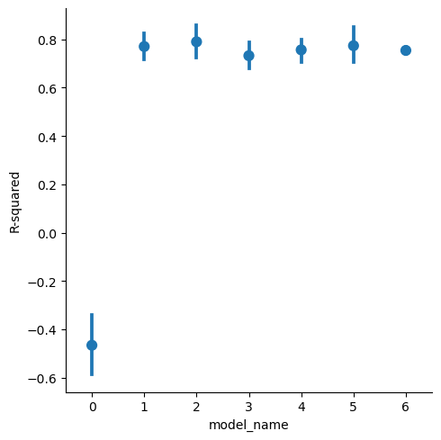

```python
sns.catplot(data = cv_score_df, x='model_name', y='R-squared', kind='point', join=False,
            errorbar=('ci', 68))

plt.show()
```

The `model_name==0` model is REALLY BAD! We are confidenct ALL models are better than `model_name==0`. Since this model is the INTERCEPT-ONLY or CONSTANT AVERAGE model, this means ALL models are BETTER than a model with NO TRENDS! R-squared values cannot actually be NEGATIVE! This is just an artifact of the formula used in scikit-learn. Let's filter the `model_name==0` model out to simplify the visualization.

As shown below, **ALL** models have OVERLAPPING confidence intervals! We therefore **cannot** distinguish between any of the models! They are ALL effectively the same AVERAGE R-squared!

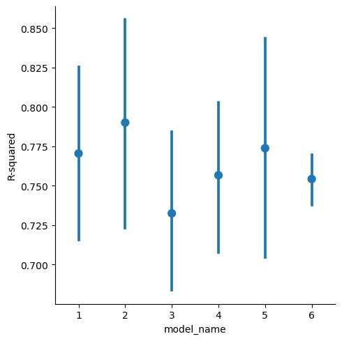

```python
sns.catplot(data = cv_score_df.loc[ cv_score_df.model_name > 0, : ],
            x='model_name', y='R-squared', kind='point', join=False,
            errorbar=('ci', 68))

plt.show()
```

When you CANNOT distinguish one model from another, choose the SIMPLEST MODEL! As shown below, the `model_name==1` model (which IS `fit_01`) has the FEWEST coefficients! Therefore we should identify `fit_01` as the BEST!

```python
cv_score_df.groupby(['model_name', 'num_coefs', 'model_formula']).\
aggregate(r2_avg=('R-squared', 'mean'),
          r2_sem=('R-squared', 'sem')).\
reset_index()
```

|  | model_name | num_coefs | model_formula | r2_avg | r2_sem |
| --- | --- | --- | --- | --- | --- |
| 0 | 0 | 1 | y ~ 1 | -0.466046 | 0.135630 |
| 1 | 1 | 3 | y ~ x1 + x2 | 0.770455 | 0.058396 |
| 2 | 2 | 4 | y ~ x1 * x2 | 0.790050 | 0.063961 |
| 3 | 3 | 5 | y ~ x1 + x2 + np.power(x1, 2) + np.power(x2, 2) | 0.732485 | 0.057523 |
| 4 | 4 | 6 | y ~ x1 * x2 + np.power(x1, 2) + np.power(x2, 2) | 0.756644 | 0.051235 |
| 5 | 5 | 6 | y ~ x1 + x2 + np.power(x1, 3) + np.power(x2, 2... | 0.773826 | 0.074753 |
| 6 | 6 | 9 | y ~ ( x1 + np.power(x1, 2) ) * ( x2 + np.power... | 0.754269 | 0.017864 |

Let's examine the performance based on RMSE. Again, we can CONFIDENTLY say ALL models are better than the INTECEPT-ONLY model!

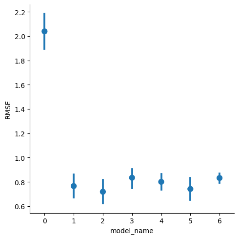

```python
sns.catplot(data = cv_score_df, x='model_name', y='RMSE', kind='point', join=False,
            errorbar=('ci', 68))

plt.show()
```

Remove `model_name==0` from the figure to focus on all other models. Even though `model_name==2` has the LOWEST average RMSE, the `model_name==1` model's performance OVERLAPS that model! Therefore, we can still select `model_name==1` and thus `fit_01` as the BEST MODEL!!!

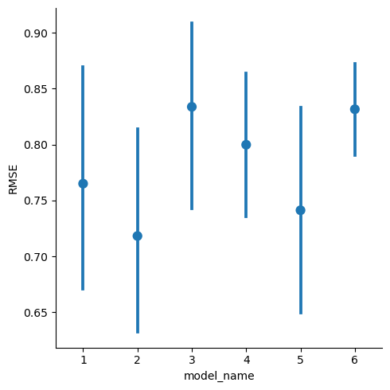

```python
sns.catplot(data = cv_score_df.loc[ cv_score_df.model_name > 0, :],
            x='model_name', y='RMSE', kind='point', join=False,
            errorbar=('ci', 68))

plt.show()
```

**Why does this matter?**

The TRAINING SET performance identified `fit_06`, the model with the MOST coefficients, as the best model. The TRAINING set R-squared was 92% compared to the `fit_01` model's TRAINING set R-squared of 87%. A value of 92% is higher than 87% and thus we might be tempted to identify the MORE COMPLEX model as the best! However, Cross-Validation revealed that the only model that was confidently WORSE than the others was the INTERCEPT-ONLY model! We are therefore CONFIDENT a TREND exists between the OUTPUT and INPUT. However, we CANNOT distinguish the performance of the remaining models! We cannot say for certain if `fit_06` is actually better than `fit_01`. Therefore, we should SELECT THE SIMPLEST OPTION!

## In Summary

This notebook reviewed fitting, evaluating, and prediction linear models from statsmodels. This notebook demonstrated how to fit `LinearRegression()` scikit-learn models and how to apply `cross_val_score()` to linear models.